# Lab01

Janish Parikh

05/08/2020

Link for github depository:https://github.com/Ansh-Ji/CS-605-Data-Analytics-in-R/tree/master/Lab1

```r
library('ggplot2')
```

Question-(01) The numbers of blocked intrusion attempts on each day during the first two weeks of the month were 56, 47, 49, 37, 38, 60, 50, 43, 43, 59, 50, 56, 54, 58. After the change of firewall settings, the numbers of blocked intrusions during the next 20 days were 53, 21, 32, 49, 45, 38, 44, 33, 32, 43, 53, 46, 36, 48, 39, 35, 37, 36, 39,45. Comparing the number of blocked intrusions before and after the change,

```r
before<-c(56, 47, 49, 37, 38, 60, 50, 43, 43, 59, 50, 56, 54, 58)
after<-c(53, 21, 32, 49, 45, 38, 44, 33, 32, 43, 53, 46, 36, 48, 39, 35, 37, 36,
         39,45)
```

1. construct side-by-side stem-and-leaf plots

```r
#stem(before)
#stem(after)
library('aplpack')
stem.leaf.backback(before,after)#use package aplpack
```

```
## __________________________________
##   1 | 2: represents 12, leaf unit: 1
##         before      after
## __________________________________
##               | 2* |1         1
##               | 2. |
##               | 3* |223       4
##    2        87| 3. |5667899  (7)
##    4        33| 4* |34        9
##    6        97| 4. |55689     7
##   (3)      400| 5* |33        2
##    5      9866| 5. |
##    1         0| 6* |
## __________________________________
## n:          14      20
## __________________________________
```

2. compute the five-point summaries

```r
summary(before)
```

```
##    Min. 1st Qu.  Median    Mean 3rd Qu.    Max.
##      37      44      50      50      56      60
```

```r
summary(after)
```

```
##    Min. 1st Qu.  Median    Mean 3rd Qu.    Max.
##   21.00   35.75   39.00   40.20   45.25   53.00
```

construct parallel boxplots

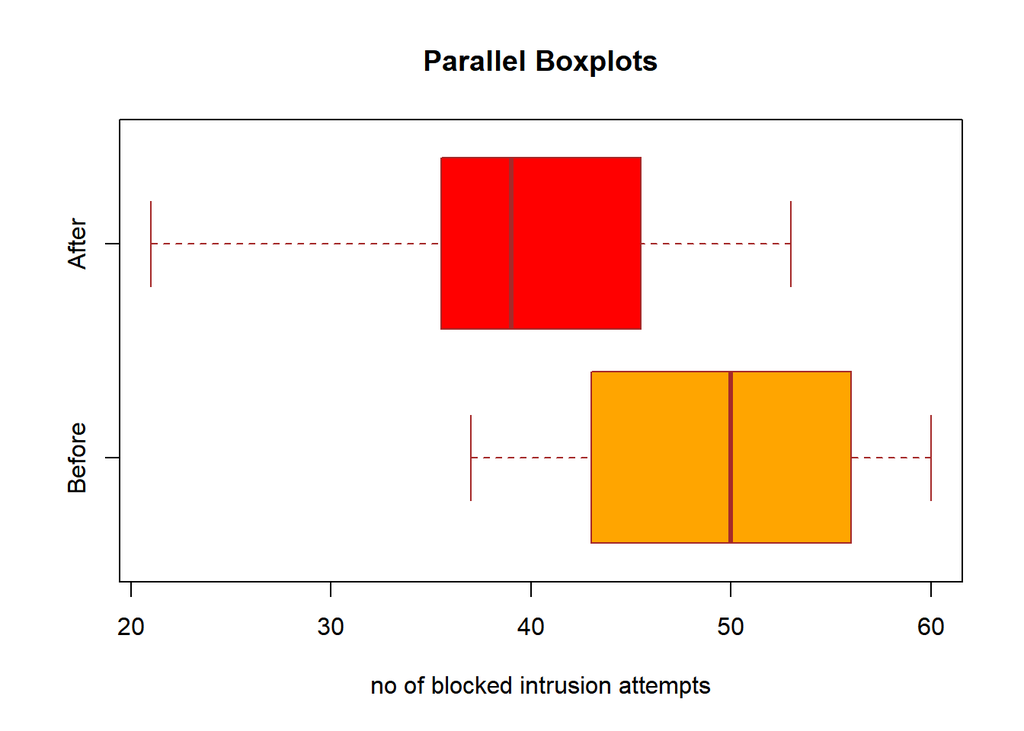

3. comment on your findings.

The mean no of blocked intrusion attempts has dropped by 9.80.

Question-(02)

A network provider investigates the load of its network. The number of concurrent users is recorded at fifty locations (thousands of people) 17.2 22.1 18.5 17.2 18.6 14.8 21.7 15.8 16.3 22.8 24.1 13.3 16.2 17.5 19.0 23.9 14.8 22.2 21.7 20.7 13.5 15.8 13.1 16.1 21.9 23.9 19.3 12.0 19.9 19.4 15.4 16.7 19.5 16.2 16.9 17.1 20.2 13.4 19.8 17.7 19.7 18.7 17.6 15.9 15.2 17.1 15.0 18.8 21.6 11.9

```r
user<-c(17.2, 22.1, 18.5, 17.2, 18.6, 14.8, 21.7, 15.8, 16.3, 22.8,  24.1, 13.3,
        16.2, 17.5, 19.0,23.9, 14.8, 22.2, 21.7, 20.7 ,13.5 ,15.8, 13.1, 16.1,
        21.9, 23.9, 19.3, 12.0, 19.9, 19.4, 15.4, 16.7, 19.5, 16.2, 16.9, 17.1,
        20.2, 13.4, 19.8, 17.7, 19.7 ,18.7, 17.6, 15.9, 15.2 ,17.1 ,15.0, 18.8,
        21.6 ,11.9)
```

```r
explore<-function(x){
  data<-c("Mean"=mean(x),"Median"=median(x),
          "Standard Deviation" = sd(x))
  return(data)
}
explore(user)
```

```
##               Mean             Median Standard Deviation
##          17.954000          17.550000           3.157253
```

2. Estimate the standard error of the sample mean.

```r
#Standard Error = s.D/sqrt(n)
standard_error<-function(x){
  se<-("Standard Error" = sd(x)/sqrt(length(x)))
  return(se)
}
standard_error(user)
```

```
## [1] 0.4465031
```

```r
library('psych')
describe(user,IQR=T)
```

```
##    vars  n  mean   sd median trimmed  mad  min  max range skew kurtosis   se
## X1    1 50 17.95 3.16  17.55   17.93 3.19 11.9 24.1  12.2 0.11    -0.79 0.45
##     IQR
## X1 4.05
```

(c)Compute the five-point summary and construct a boxplot.

```r
summary(user)
```

```
##    Min. 1st Qu.  Median    Mean 3rd Qu.    Max.
##   11.90   15.82   17.55   17.95   19.88   24.10
```

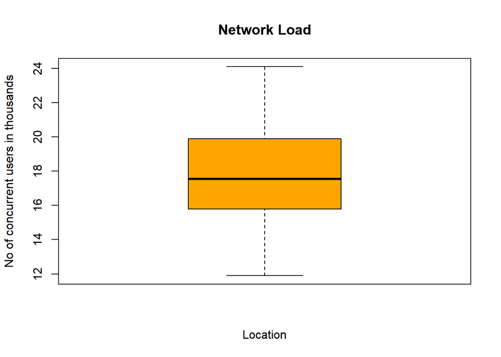

4. Compute the interquartile range. Are there any outliers?

```r
# IQR is measure of statistical dispersion IQR=Q3-Q1
Q1<-quantile(user,0.25)
Q3<-quantile(user,0.75)
IQR<-Q3-Q1
print(IQR)
```

```
##  75%
## 4.05
```

```r
#Used 1.5 IQR
left<- (Q1-(1.5*IQR))
right<- (Q3+(1.5*IQR))
outliers<-c(user[user <left],user[user>right])
print(outliers)
```

```
## numeric(0)
```

There are no Outliers

(e)It is reported that the number of concurrent users follows approximately Normal distribution. Does the histogram support this claim?

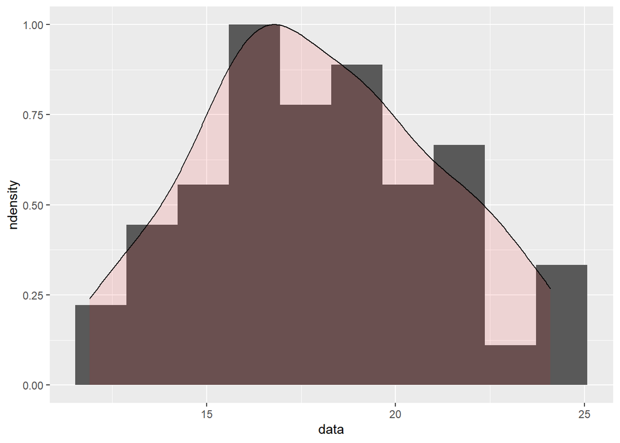

The distribution looks like a normal distribution

Question-(03)

Consider three data sets. (1) 19, 24, 12, 19, 18, 24, 8, 5, 9, 20, 13, 11, 1, 12, 11, 10, 22, 21, 7, 16, 15, 15, 26, 16, 1, 13, 21, 21, 20, 19 (2) 17, 24, 21, 22, 26, 22, 19, 21, 23, 11, 19, 14, 23, 25, 26, 15, 17, 26, 21, 18, 19, 21, 24, 18, 16, 20, 21, 20, 23, 33 (3) 56, 52, 13, 34, 33, 18, 44, 41, 48, 75, 24, 19, 35, 27, 46, 62, 71, 24, 66, 94, 40, 18, 15, 39, 53, 23, 41, 78, 15, 35

```r
dataset1<-c(19, 24, 12, 19, 18, 24, 8, 5, 9, 20, 13, 11, 1, 12, 11, 10, 22, 21, 7, 16,
        15, 15, 26, 16, 1, 13, 21, 21, 20, 19)
dataset2<-c(17, 24, 21, 22, 26, 22, 19, 21, 23, 11, 19, 14, 23, 25, 26, 15, 17, 26,
        21, 18, 19, 21, 24, 18, 16, 20, 21, 20, 23, 33)
dataset3<-c(56, 52, 13, 34, 33, 18, 44, 41, 48, 75, 24, 19, 35, 27, 46, 62, 71, 24,
        66, 94, 40, 18, 15, 39, 53, 23, 41, 78, 15, 35)
```

1. For each data set, draw a histogram and determine whether the distribution is rightskewed, left-skewed, or symmetric

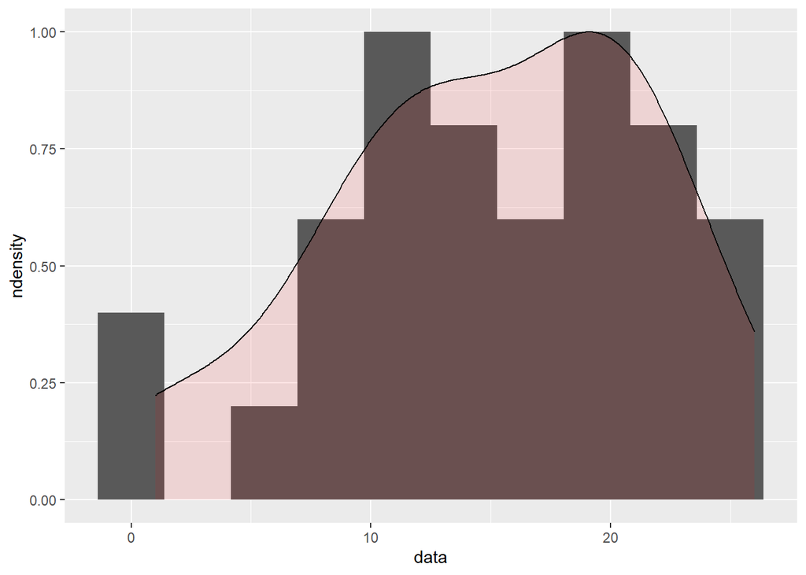

   Left Skewed

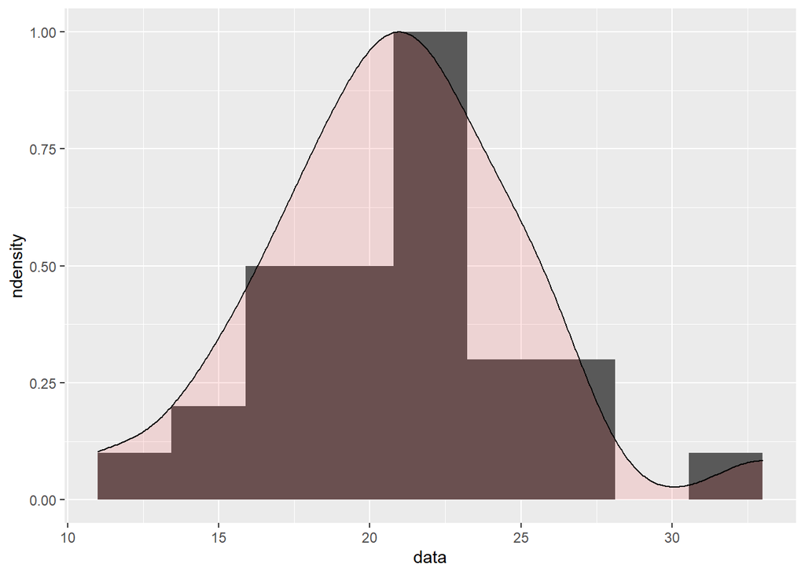

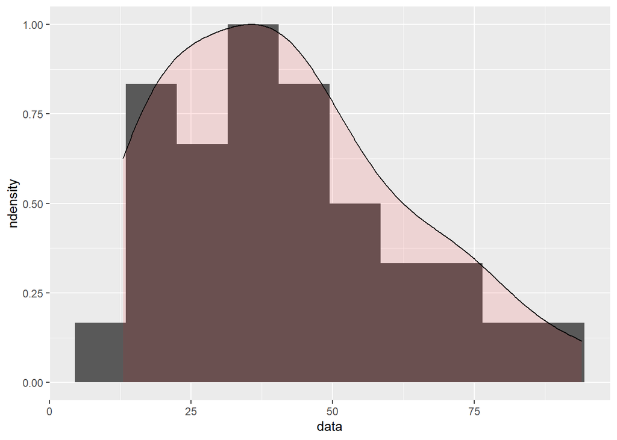

   Right Skewed
2. Compute sample means and sample medians.

```r
#function to calculate sample mean and median
sample_mean_median<-function(x){
  data<-c("Mean"=mean(x),"Median"=median(x))
  return(data)}
sample_mean_median(dataset1)
```

```
##     Mean   Median
## 14.96667 15.50000
```

```r
sample_mean_median(dataset2)
```

```
##     Mean   Median
## 20.83333 21.00000
```

```r
sample_mean_median(dataset3)
```

```
##   Mean Median
##   41.3   39.5
```

(b)Do they support your findings about skewness and symmetry? How?

```r
mean(dataset1)-median(dataset1)
```

```
## [1] -0.5333333
```

As mean is less than median we can say it is left skewed

```r
mean(dataset3)-median(dataset3)
```

```
## [1] 1.8
```

As mean is greater than median it is right skewed

We can determine the same(not always correct) via the help of histogram If the histogram has a longer left tail then we call it to be left skewed, same follows for right

Question-(04) The following data set represents the number of new computer accounts registered during ten consecutive days. 43, 37, 50, 51, 58, 105, 52, 45, 45, 10

```r
dataset<-c(43, 37, 50, 51, 58, 105, 52, 45, 45, 10)
```

1. Compute the mean, median, quartiles, and standard deviation

```r
explore<-function(x){
  data<-c("Mean"=mean(x),"Median"=median(x),
          "Standard Deviation" = sd(x),"Quartile-" =quantile(x))

  return(data)
}
explore(dataset)
```

```
##               Mean             Median Standard Deviation       Quartile-.0%
##            49.6000            47.5000            23.4767            10.0000
##      Quartile-.25%      Quartile-.50%      Quartile-.75%     Quartile-.100%
##            43.5000            47.5000            51.7500           105.0000
```

2. Check for outliers using the 1.5(IQR) rule.

```r
###Below Q1-1.5*IQR  or above Q3+1.5*IQR, where Q1 and Q3 are the first and third
#quartiles, respectively, of the variable distribution and IQR=Q3-Q1 is the
#interquartile range.

IQR_outliers <- function(x) {
  Q1<-quantile(x,0.25)
  Q3<-quantile(x,0.75)
  IQR<-(Q3-Q1) #inter-quartile range
  left<- (Q1-(1.5*IQR))
  right<- (Q3+(1.5*IQR))
  outliers<-c(x[x <left],x[x>right])
  return(outliers)
}
outliers<-IQR_outliers(dataset)
print(outliers)
```

```
## [1]  10 105
```

3. Delete the detected outliers

```r
reconstructed_dataset<-dataset[!dataset%in%outliers]
print(reconstructed_dataset)
```

```
## [1] 43 37 50 51 58 52 45 45
```

compute the mean, median, quartiles, and standard deviation again

```r
explore(reconstructed_dataset)
```

```
##               Mean             Median Standard Deviation       Quartile-.0%
##          47.625000          47.500000           6.457277          37.000000
##      Quartile-.25%      Quartile-.50%      Quartile-.75%     Quartile-.100%
##          44.500000          47.500000          51.250000          58.000000
```

4. Make a conclusion about the effect of outliers on basic descriptive statistics We can do this by analyzing the changes in Mean, Median, Standard Deviation

```r
difference<-explore(dataset)-explore(reconstructed_dataset)
```

Quartile .50% or Median remains unchanged

Standard Deviation decreases by 17.01943

Mean is affected

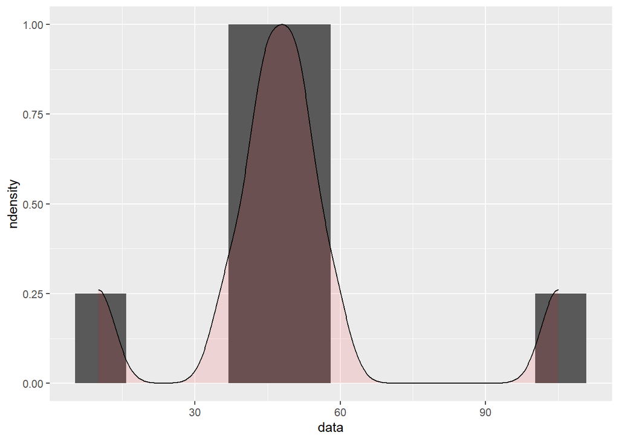

```r
#function to plot histogram
plot_histogram<-function(x){
  p<-ggplot(data=data.frame(data=x),aes(x=data))+
    geom_histogram(aes(y=stat(ndensity)),bins=10)+
    geom_density(aes(y=stat(scaled)),fill = "red",alpha = 0.1)
  plot(p)
}
plot_histogram(dataset)
```

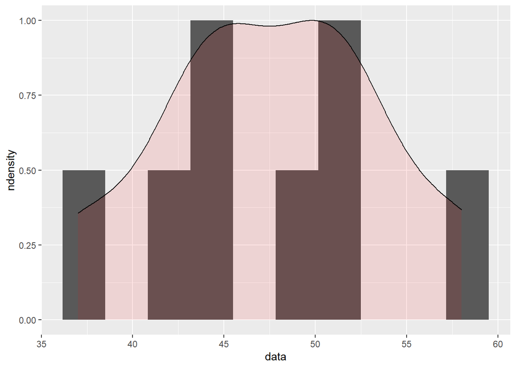

```r
plot_histogram(reconstructed_dataset)
```

After removing the outliers we can see that the spread of data has decreased and the data is more closely distributed.